# PA1_template

Xinli

May 30, 2016

- Loading and preprocessing the data

```r
setwd("~/Desktop/reproducible_research_coursera")
dat <- read.csv("activity.csv")
dat$date <- as.Date(dat$date, format="%Y-%m-%d")
```

- What is mean total number of steps taken per day

```r
library(dplyr)
total_steps <- dat %>% group_by(date) %>%summarize(total_steps=sum(steps, na.rm=T))
```

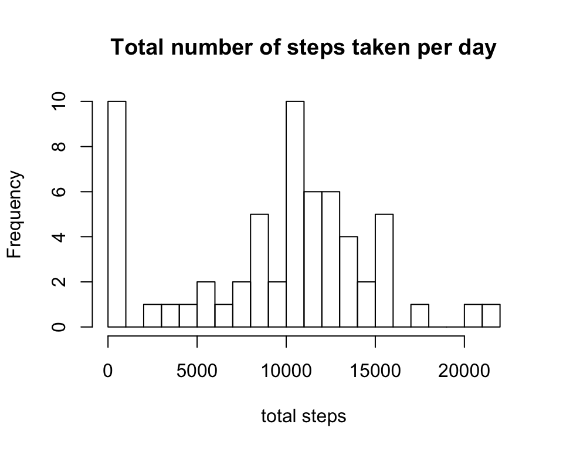

```r
hist(total_steps$total_steps, breaks=30,main = "Total number of steps taken per day", xlab = "total steps")
```

```r
mean <- mean(total_steps$total_steps, na.rm = T)
mean
```

```
## [1] 9354.23
```

```r
med <- median(total_steps$total_steps, na.rm = T)
med
```

```
## [1] 10395
```

So the mean of the total number of steps taken per day is 9354.2295082, median is 10395.

- What is the average daily activity patter?

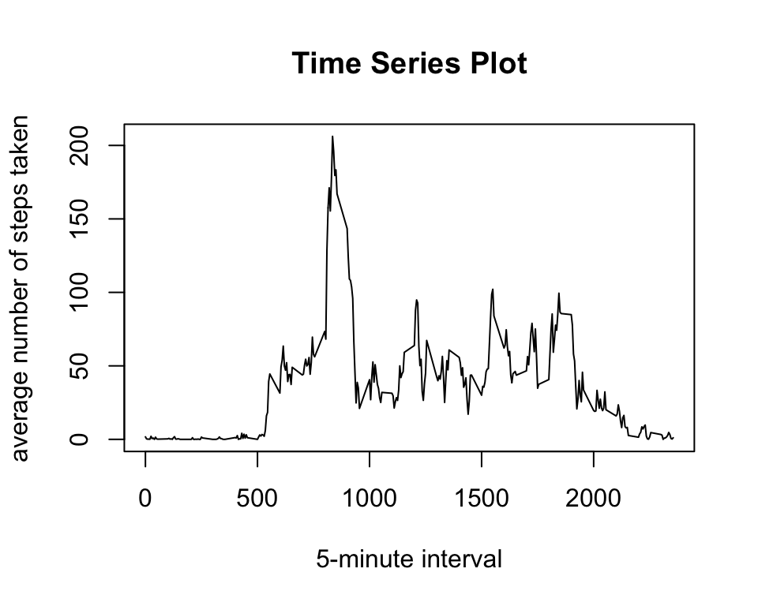

```r
average_interval <- dat %>% group_by(interval) %>% summarize(average=mean(steps,na.rm=T))
plot(average_interval$interval, average_interval$average, type = 'l', xlab = "5-minute interval", ylab="average number of steps taken", main = "Time Series Plot")
```

```r
maximum = which.max(average_interval$average)
average_interval[maximum, ]
```

```
## Source: local data frame [1 x 2]
##
##   interval  average
##      (int)    (dbl)
## 1      835 206.1698
```

- Imputing missing values

```r
total_missing <- sum(is.na(dat$steps))
total_missing
```

```
## [1] 2304
```

So the total number of missing values in the dataset is 2304.

Filling in the missing values using mean for that 5-minute interval.

```r
combined <- merge(dat, average_interval, by="interval", all.x = T)
combined$steps <- ifelse(is.na(combined$steps), combined$average, combined$steps)
dat.1 <- combined[,1:3]
```

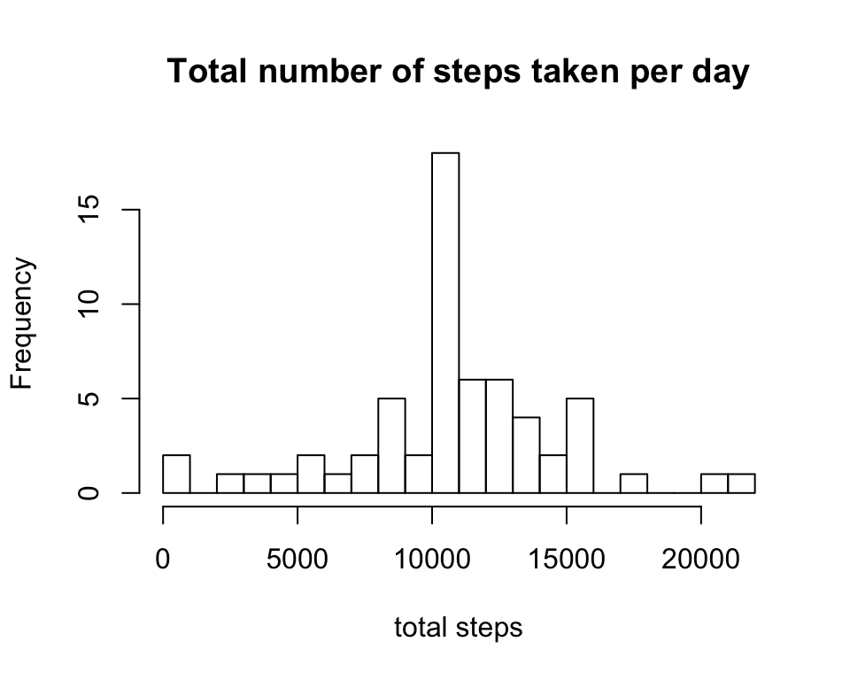

```r
total_steps.1 <- dat.1 %>% group_by(date) %>% summarise(total=sum(steps))
hist(total_steps.1$total,breaks = 30, main = "Total number of steps taken per day",xlab = "total steps")
```

```r
mean.1 <-mean(total_steps.1$total)
med.1 <- median(total_steps.1$total)
```

After imputing missing values using means of 5-minute intervals, the mean of total number of steps taken per day in new dataset is 10766, the median is 10766.

The impact of imputing missing data on the estimates of the total daily number of steps is the mean of total number of steps equals to the median.

- Are there differences in activity patterns between weekdays and weekends?

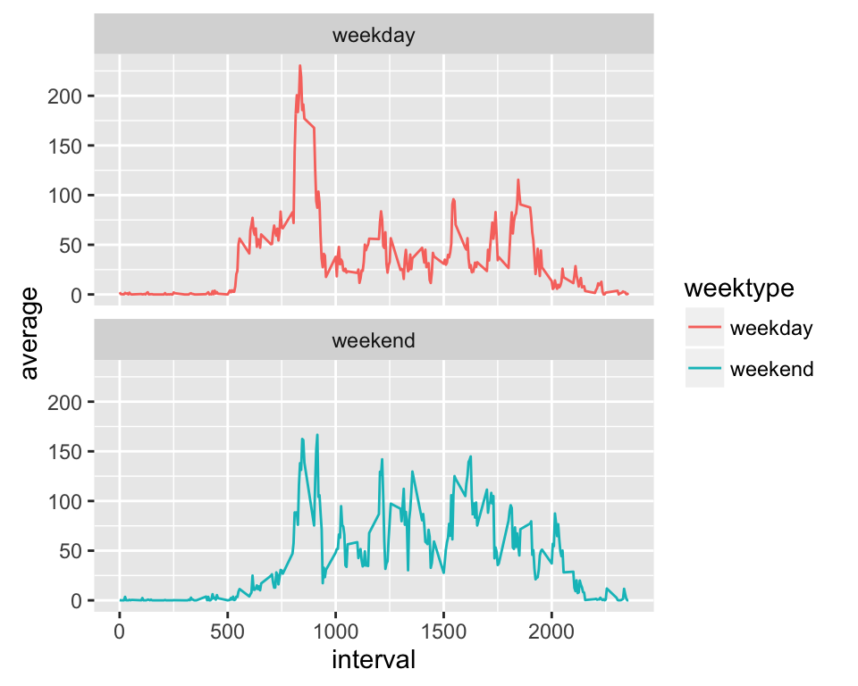

```r
dat.1$weekday <- weekdays(dat.1$date)
dat.1$weektype <- ifelse(dat.1$weekday %in% c("Saturday", "Sunday"), "weekend", "weekday")
average_steps <- dat.1 %>% group_by(weektype, interval) %>%
    summarize(average=mean(steps))
library(ggplot2)
p <- ggplot(average_steps, aes(x=interval,y=average,color=weektype))+
    geom_line()+
    facet_wrap(~weektype,ncol = 1, nrow = 2)
p
```